# Introduction to antibody affinity measurements

Katharina Imkeller

15. June 2020

# Antibody diversity, specificity and affinity

Antibodies are protein secreted by B cells upon an immune reaction to a specific antigen. These antibodies are able to specifically recognize their target antigen - the antibody affinity is thereby representative of the binding strength between antibody and antigen. There is a very high diversity in the antibody molecules, i.e. every naive B cell produces a unique antibody molecule. This diversity is enabled by somatic recombination of gene segments that encode the antibody molecule, a process also known as V(D)J recombination, which takes place during B cell development. In addition to V(D)J recombination, every antibody is composed of a heavy and a light chain, which are also randomly paired during B cell development. During an immune reaction, the antibody encoding genes undergo somatic hypermutation, and eventually increase the affinity to their target antigen, a process called affinity maturation. For a more detailed review of the underlying processes, please refer to the lectures or this [review by K. Rajewski](https://www.nature.com/articles/381751a0.pdf).

Different experimental methods exist to asses antibody-antigen binding and affinity, among them the enzyme-linked immunosorbent assay (ELISA).

## ELISA

The enzyme-linked immunosorbent assay (ELISA) is one of the most frequently used assays in immunological research. While it is not the most quantitative assay (small linear range), it is cheap, has a high sensitivity, is easy to setup and only requires a simple absorbance reader.

In this assay, high-binding plates (e.g. 96-well plates) are coated with the antigen of interest and unspecific binding is blocked by incubation with blocking buffer containing BSA. After washing, the antibodies of interest are added to the different wells in different concentrations (e.g. 4$\mu$g/mL, 1$\mu$g/mL, 0.25$\mu$g/mL, 0.0625$\mu$g/mL) and incubated. The plates are washed again and a secondary (anti-antibody) antibody is added, which binds to the constant regions of the antibodies of interest. The secondary antibody is typically coupled to an peroxidase-enzyme, which reacts with a substrate that is added in the next step. The color change in the substrate solution is more or less proportional to the amount of peroxidase, i.e. the amount of secondary antibody, i.e. the amount of antibody of interest that has remained bound to the coating antigen after washing.

The color of the substrate can be quantified in a plate absorbance reader by measuring the optical density at a given wavelength in every well of the plate. The absorbance data can be summarized into “area under the curve” (AUC) to compare the antigen reactivity of different antibodies. The AUC is calculated for the curve of optical density (y-axis) versus antibody concentration (x-axis).

Example of ELISA optical density and calculation of area under the curve:

```r
concentrations <- c(4,1,0.25,0.0625)
non_reactive_ods <- c(0.1,0.06,0.05,0.04)
reactive_ods <- c(1.8,1.4,0.6,0.2)

abdf <- data.frame(ab_concentration = concentrations,
           not_reactive = non_reactive_ods,
           reactive = reactive_ods)
```

In the following plot the optical density for different antibody concentrations for a reactive (red) and a non-reactive (black) antibody are shown:

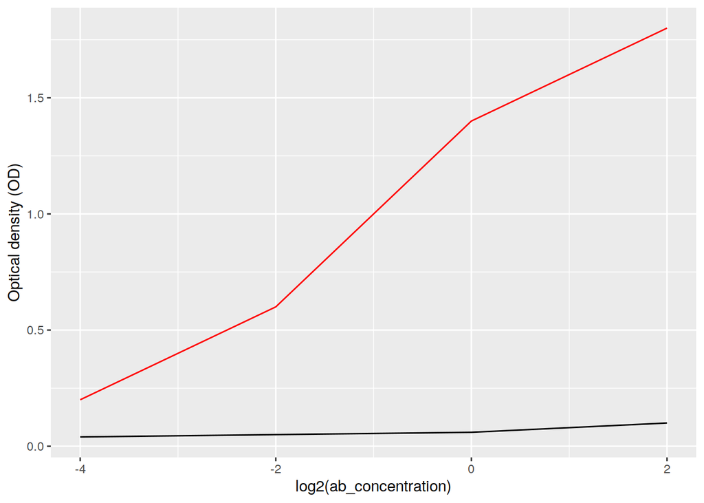

```r
abdf %>%
    ggplot(aes(x = log2(ab_concentration))) +
    geom_line(aes(y = not_reactive)) +
    geom_line(aes(y = reactive), color = "red") +
    ylab("Optical density (OD)")
```

Define a AUC calculation function which takes the 4 optical densities as input:

```r
calculate_auc <- function(ods) {
    step_width <- 2
    rectangular_part <- ods[2:4]*2
    triangular_part <- ods[1:3] - ods[2:4] # *2 and /2
    sum(rectangular_part, triangular_part)
}
```

AUC of the non-reactive antibody:

```r
calculate_auc(non_reactive_ods)
```

```
## [1] 0.36
```

AUC of the reactive antibody:

```r
calculate_auc(reactive_ods)
```

```
## [1] 6
```